# Mining, Classification, Prediction

## *Abigail Tovar art2976*

### Introduction

For this research project, I selected to use an insurance dataset that included factors such as Age, Sex, BMI, Number of Children, Smoker, and Region. These variables are an important component as to how insurance companies determine the health condition of persons requesting for coverage in order to determine premiums. I chose this dataset because I was especially interested in what types of big data health insurance use to determine charges, and how linear regression/machine learning and further data analysis might be able to predict the premiums that specific groups would pay.

```r
library(tidyverse)
library(dplyr)
insurance <- read_csv(file = "/stor/home/art2976/insurance.csv")

# I changed the smoker variables to binary where '1' = yes,
# and '0' = no.

tidy_insurance <- insurance %>% mutate(smoker = ifelse(smoker ==
    "no", 0, 1))

tidy_insurance
```

```
## # A tibble: 1,338 x 7
##      age sex      bmi children smoker region    charges
##    <dbl> <chr>  <dbl>    <dbl>  <dbl> <chr>       <dbl>
##  1    19 female  27.9        0      1 southwest  16885.
##  2    18 male    33.8        1      0 southeast   1726.
##  3    28 male    33          3      0 southeast   4449.
##  4    33 male    22.7        0      0 northwest  21984.
##  5    32 male    28.9        0      0 northwest   3867.
##  6    31 female  25.7        0      0 southeast   3757.
##  7    46 female  33.4        1      0 southeast   8241.
##  8    37 female  27.7        3      0 northwest   7282.
##  9    37 male    29.8        2      0 northeast   6406.
## 10    60 female  25.8        0      0 northwest  28923.
## # … with 1,328 more rows
```

```r
tidy_insurance_2 <- insurance %>% mutate(smoker = ifelse(smoker ==
    "no", 0, 1))
```

### Cluster Analysis

```r
library(cluster)
library(ggplot2)
library(GGally)


set.seed(624)
pam1 <- tidy_insurance %>% pam(k = 2)  #use the pam function
pam1
```

```
## Medoids:
##       ID age sex    bmi children smoker region  charges
## [1,] 986  44  NA 25.800        1      0     NA  7624.63
## [2,] 264  19  NA 36.955        0      1     NA 36219.41
## Clustering vector:
##   [1] 1 1 1 2 1 1 1 1 1 2 1 2 1 1 2 1 1 1 1 2 1 1 1 2 1 1 1 1 1 2 2 1 1 1 2 1 1
##  [38] 1 2 2 1 1 1 1 1 1 1 1 1 2 1 1 2 2 1 2 1 2 2 1 1 1 2 1 1 1 1 1 1 1 1 1 1 1
##  [75] 1 1 1 1 1 1 1 1 2 1 2 1 2 1 1 1 1 1 2 1 2 1 1 1 2 1
##  [ reached getOption("max.print") -- omitted 1238 entries ]
## Objective function:
##    build     swap
## 5835.084 5659.556
##
## Available components:
##  [1] "medoids"    "id.med"     "clustering" "objective"  "isolation"
##  [6] "clusinfo"   "silinfo"    "diss"       "call"       "data"
```

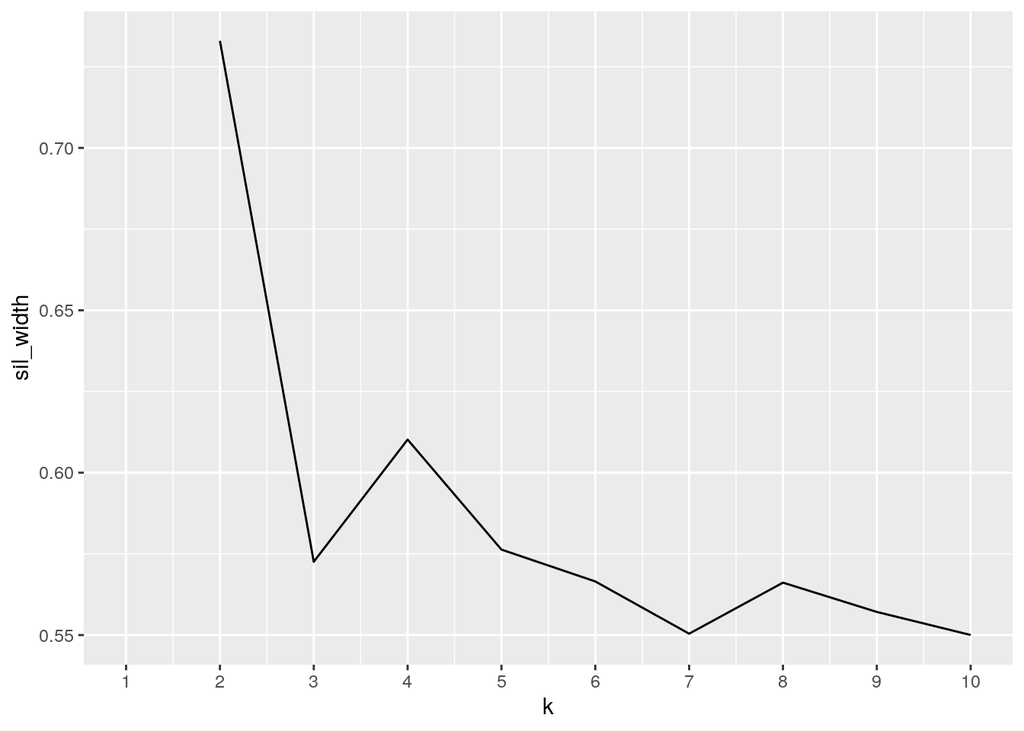

```r
sil_width <- vector()
for (i in 2:10) {
    pam_fit <- pam(tidy_insurance, k = i)
    sil_width[i] <- pam_fit$silinfo$avg.width
}
ggplot() + geom_line(aes(x = 1:10, y = sil_width)) + scale_x_continuous(name = "k",
    breaks = 1:10)
```

[figure not shown]

```r
plot(pam1, which = 2)
```